# Visualizing Bay Wheels Bikes

## Clean

```python
# before clean, save to new df before cleaning
baywheelstrip_clean = baywheelstrip.copy()
```

**Defined & Code**

```python
# convert start/end to datetime formate
baywheelstrip_clean.started_at = pd.to_datetime(baywheelstrip_clean.started_at)
baywheelstrip_clean.ended_at = pd.to_datetime(baywheelstrip_clean.ended_at)
```

**Test**

```python
baywheelstrip_clean.info()
# success convert 👍
```

```
<class 'pandas.core.frame.DataFrame'>
RangeIndex: 154967 entries, 0 to 154966
Data columns (total 13 columns):
 #   Column              Non-Null Count   Dtype
---  ------              --------------   -----
 0   ride_id             154967 non-null  object
 1   rideable_type       154967 non-null  object
 2   started_at          154967 non-null  datetime64[ns]
 3   ended_at            154967 non-null  datetime64[ns]
 4   start_station_name  102589 non-null  object
 5   start_station_id    102589 non-null  float64
 6   end_station_name    100407 non-null  object
 7   end_station_id      100407 non-null  float64
 8   start_lat           154967 non-null  float64
 9   start_lng           154967 non-null  float64
 10  end_lat             154771 non-null  float64
 11  end_lng             154771 non-null  float64
 12  member_casual       154967 non-null  object
dtypes: datetime64[ns](2), float64(6), object(5)
memory usage: 15.4+ MB
```

**Defined, Code, Test**

```python
# Add new column for duration of the trip
baywheelstrip_clean['duration'] = baywheelstrip_clean.ended_at - baywheelstrip_clean.started_at

# reorder columns, to make duration next to trip time
col = ['ride_id', 'rideable_type', 'started_at', 'ended_at', 'duration',
       'start_station_name', 'start_station_id', 'end_station_name',
       'end_station_id', 'start_lat', 'start_lng', 'end_lat', 'end_lng',
       'member_casual']


baywheelstrip_clean = baywheelstrip_clean.reindex(columns=col)

baywheelstrip_clean.head()
# success add 👍
```

|  | ride_id | rideable_type | started_at | ended_at | duration | start_station_name | start_station_id | end_station_name | end_station_id | start_lat | start_lng | end_lat | end_lng | member_casual |
| --- | --- | --- | --- | --- | --- | --- | --- | --- | --- | --- | --- | --- | --- | --- |
| 0 | 68213B7BB2420043 | electric_bike | 2020-07-31 17:36:17 | 2020-07-31 17:48:13 | 00:11:56 | NaN | NaN | McAllister St at Baker St | 52.0 | 37.790000 | -122.460000 | 37.777414 | -122.441949 | casual |
| 1 | A64F0CD3A8E59529 | electric_bike | 2020-07-31 19:42:50 | 2020-07-31 19:49:54 | 00:07:04 | Buchanan St at North Point St | 400.0 | Buchanan St at North Point St | 400.0 | 37.804388 | -122.433510 | 37.804408 | -122.433509 | casual |
| 2 | B3690CA0F5179242 | electric_bike | 2020-07-31 17:18:46 | 2020-07-31 17:36:31 | 00:17:45 | NaN | NaN | Hyde St at Post St | 369.0 | 37.760000 | -122.410000 | 37.787422 | -122.416777 | casual |
| 3 | 162FFE2E157F4C8F | electric_bike | 2020-07-31 20:48:47 | 2020-07-31 21:05:04 | 00:16:17 | Jersey St at Castro St | 137.0 | NaN | NaN | 37.750576 | -122.433743 | 37.770000 | -122.420000 | casual |
| 4 | C5DA8100F428B934 | electric_bike | 2020-07-31 20:18:24 | 2020-07-31 20:24:26 | 00:06:02 | Market St at Steuart St | 16.0 | NaN | NaN | 37.794582 | -122.394791 | 37.790000 | -122.400000 | casual |

**Defined**

```python
# check trip durations
baywheelstrip_clean.duration.sort_values(ascending=False)
```

```
148860    26 days 00:20:01
119392    23 days 01:13:55
102212    21 days 20:19:57
143282    18 days 18:30:58
129145    18 days 14:53:00
                ...
115389   -1 days +23:59:14
127719   -1 days +23:52:29
112573   -1 days +23:34:12
100659   -1 days +23:21:21
105209   -1 days +22:57:18
Name: duration, Length: 154967, dtype: timedelta64[ns]
```

**comment:**

- Some rows have negative duration!!
- Someone ride a bike for 26 days!
- Some rows have duration for 1 sec!

```python
# Check negative/zero duration
baywheelstrip_clean.query('duration <= "00:00:00"')
```

|  | ride_id | rideable_type | started_at | ended_at | duration | start_station_name | start_station_id | end_station_name | end_station_id | start_lat | start_lng | end_lat | end_lng | member_casual |
| --- | --- | --- | --- | --- | --- | --- | --- | --- | --- | --- | --- | --- | --- | --- |
| 2657 | CBCE03F639AA7EB1 | electric_bike | 2020-07-13 21:02:45 | 2020-07-13 21:02:45 | 00:00:00 | Steiner St at California St | 480.0 | NaN | NaN | 37.788536 | -122.435417 | 37.790000 | -122.440000 | casual |
| 6245 | 21A9F6F9F79F2286 | electric_bike | 2020-07-26 16:07:50 | 2020-07-26 16:07:50 | 00:00:00 | Market St at Dolores St | 86.0 | NaN | NaN | 37.769184 | -122.427034 | 37.770000 | -122.430000 | casual |
| 6361 | 26DD27610190C800 | electric_bike | 2020-07-28 15:40:19 | 2020-07-28 15:40:19 | 00:00:00 | Grove St at Masonic Ave | 375.0 | NaN | NaN | 37.774792 | -122.446756 | 37.770000 | -122.450000 | casual |
| 10231 | 26345752F6FCE010 | electric_bike | 2020-07-05 16:10:23 | 2020-07-05 16:10:23 | 00:00:00 | Civic Center/UN Plaza BART Station (Market St ... | 44.0 | NaN | NaN | 37.781018 | -122.411696 | 37.780000 | -122.410000 | casual |
| 10282 | 657B16587C643382 | electric_bike | 2020-07-15 18:48:34 | 2020-07-15 18:48:34 | 00:00:00 | Market St at Dolores St | 86.0 | NaN | NaN | 37.769304 | -122.426879 | 37.770000 | -122.430000 | casual |
| ... | ... | ... | ... | ... | ... | ... | ... | ... | ... | ... | ... | ... | ... | ... |
| 152261 | A56B64AC54122853 | docked_bike | 2020-07-21 08:13:55 | 2020-07-21 08:13:54 | -1 days +23:59:59 | Howard St at Beale St | 22.0 | Terry Francois Blvd at Warriors Way | 460.0 | 37.789756 | -122.394643 | 37.769095 | -122.386333 | member |
| 152618 | 711888EC83645889 | docked_bike | 2020-07-21 06:32:56 | 2020-07-21 06:32:54 | -1 days +23:59:58 | Market St at Steuart St | 16.0 | The Embarcadero at Bryant St | 28.0 | 37.794497 | -122.394838 | 37.787168 | -122.388098 | member |
| 153622 | EFF3045C4AF10ACE | docked_bike | 2020-07-25 17:30:47 | 2020-07-25 17:30:41 | -1 days +23:59:54 | 22nd St at Potrero Ave | 518.0 | Cruise Terminal at Pier 27 | 462.0 | 37.756808 | -122.405943 | 37.804648 | -122.402087 | member |
| 154119 | 0351C1AF525CC839 | docked_bike | 2020-07-20 21:14:49 | 2020-07-20 21:14:40 | -1 days +23:59:51 | Funston Ave at Irving St | 450.0 | Laguna St at Hayes St | 74.0 | 37.763934 | -122.470650 | 37.776435 | -122.426244 | member |
| 154611 | CC660375345BECC3 | docked_bike | 2020-07-20 23:08:40 | 2020-07-20 23:08:38 | -1 days +23:59:58 | Cruise Terminal at Pier 27 | 462.0 | Davis St at Jackson St | 11.0 | 37.804648 | -122.402087 | 37.797280 | -122.398436 | casual |

95 rows × 14 columns

```python
# Total numbers of negative/zero duration
baywheelstrip_clean.query('duration <= "00:00:00"').shape[0]
```

```
95
```

```python
# Let assume for zero duration data, entered without the bike moving or signal issues

# Let assume for negative duration, data was swap(between start/end point)
# Check first ride_id D38D72366DB8A675, using google map
Image(url= "https://i.imgur.com/xxLGkF7.png")

# The minimum route take 27min not 24sec(-1 days +23:59:36)
# The assumption for negative duration was rejected
```

[figure not shown]

**Defined & Code**

```python
# Fix 95 row is a time consuming task, therefore drop these rows
# Save index in a list
negative_duration_index = baywheelstrip_clean.query('duration <= "00:00:00"').index

# Drop these rows
baywheelstrip_clean.drop(negative_duration_index, inplace = True)
```

**Test**

```python
baywheelstrip_clean.query('duration <= "00:00:00"')
# success drop 👍
```

|  | ride_id | rideable_type | started_at | ended_at | duration | start_station_name | start_station_id | end_station_name | end_station_id | start_lat | start_lng | end_lat | end_lng | member_casual |
| --- | --- | --- | --- | --- | --- | --- | --- | --- | --- | --- | --- | --- | --- | --- |

**Defined & Code**

```python
# Total number of times when start/end latitudes are the same
baywheelstrip_clean.query('start_lat == end_lat').shape[0]
```

```
16976
```

```python
# Total number of rows in dataframe
baywheelstrip_clean.shape[0]
```

```
154872
```

```python
# Check start/end latitudes
ind = baywheelstrip_clean.query('start_lat == end_lat').index

# drop these rows
baywheelstrip_clean.drop(ind, inplace = True)
```

**Test**

```python
# Total number of rows after drop
baywheelstrip_clean.shape[0]
# success drop 👍
```

```
137896
```

```python
# Total number of times when start/end longitude are the same
baywheelstrip_clean.query('start_lng == end_lng').shape[0]
```

```
5096
```

```python
# Check start/end longitude
ind = baywheelstrip_clean.query('start_lng == end_lng').index

# drop these rows
baywheelstrip_clean.drop(ind, inplace = True)
```

**Test**

```python
# Total number of rows after drop
baywheelstrip_clean.shape[0]
# success drop 👍
```

```
132800
```

# Visualization

**Univariate Exploration**

```python
# set base color for all graphs
base_color = sns.color_palette()[0]
```

```python
# Timeframe analysis for the dataset
print('Started:', baywheelstrip_clean.started_at.min(),'- Ended:', baywheelstrip_clean.started_at.max())
```

```
Started: 2020-07-01 00:01:51 - Ended: 2020-07-31 23:58:49
```

```python
# Create df for frequent of trips
daily_trips = baywheelstrip_clean.groupby(pd.Grouper(key = 'started_at', freq = "D")).count().reset_index()

daily_trips = daily_trips[['started_at','ride_id']]
daily_trips.sort_values(by='ride_id',ascending=False)[:5]
```

|  | started_at | ride_id |
| --- | --- | --- |
| 10 | 2020-07-11 | 6019 |
| 24 | 2020-07-25 | 5751 |
| 17 | 2020-07-18 | 5536 |
| 11 | 2020-07-12 | 5174 |
| 3 | 2020-07-04 | 4932 |

**comment:**

- Top 3 trip days were Saturday

```python
daily_trips.sort_values(by='ride_id')[:4]
```

|  | started_at | ride_id |
| --- | --- | --- |
| 12 | 2020-07-13 | 3385 |
| 19 | 2020-07-20 | 3406 |
| 26 | 2020-07-27 | 3557 |
| 5 | 2020-07-06 | 3649 |

**comment:**

- Least 4 trip days were on Monday

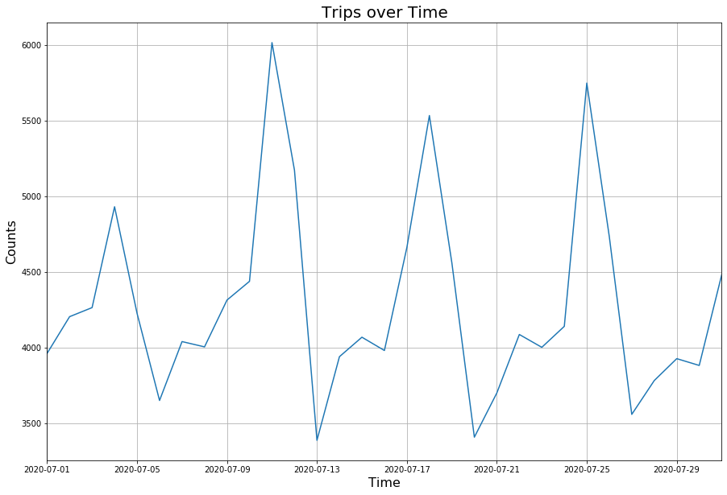

```python
# Plot Trip Counts over Time
plt.figure(figsize=(15, 10))
plt.xlim([datetime.date(2020, 7, 1), datetime.date(2020, 7, 31)])

plt.xlabel('Time', fontsize = 16)
plt.ylabel('Counts', fontsize = 16)
plt.grid()
plt.plot(daily_trips.started_at, daily_trips.ride_id)
plt.title('Trips over Time', fontsize = 20);
```

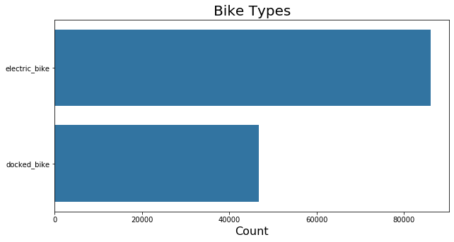

```python
# Plot bikes used
plt.figure(figsize=(10, 5))
sns.countplot(data = baywheelstrip_clean, y = 'rideable_type', color = base_color);
plt.title("Bike Types", fontsize = 20)
plt.ylabel("");
plt.xlabel("Count", fontsize = 16);
```

**comment:**

- Electric bikes twice docked bike

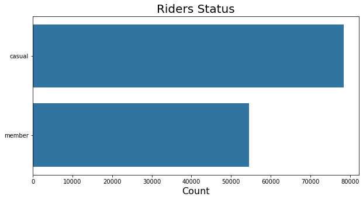

```python
# Plot bike users
plt.figure(figsize=(10, 5))
sns.countplot(data = baywheelstrip_clean, y = 'member_casual', color = base_color);
plt.title("Riders Status", fontsize = 20)
plt.ylabel("");
plt.xlabel("Count", fontsize = 16);
```

**comment:**

- Member riders 2/3 casual riders

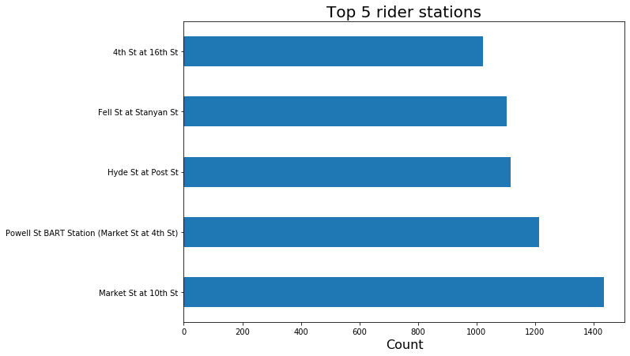

```python
plt.figure(figsize=(10, 7))
baywheelstrip_clean['start_station_name'].value_counts()[0:5].plot(kind = 'barh');
plt.title("Top 5 rider stations", fontsize = 20)
plt.ylabel("");
plt.xlabel("Count", fontsize = 16);
```

```python
# Check these stations on google map
Image(url= "https://i.imgur.com/wcowy8R.png")
```

[figure not shown]

**comment:**

- Most Popular stations are in San Francisco

```python
# Create days of the week
weekdays = ("Monday","Tuesday","Wednesday","Thursday","Friday","Saturday","Sunday")

# Creating "Appointment_week_day" which to show what day of the week the appointment was scheduled
baywheelstrip_clean['weekday'] = baywheelstrip_clean['started_at'].apply(lambda x: weekdays[x.weekday()])

baywheelstrip_clean.head()
```

|  | ride_id | rideable_type | started_at | ended_at | duration | start_station_name | start_station_id | end_station_name | end_station_id | start_lat | start_lng | end_lat | end_lng | member_casual | weekday |
| --- | --- | --- | --- | --- | --- | --- | --- | --- | --- | --- | --- | --- | --- | --- | --- |
| 0 | 68213B7BB2420043 | electric_bike | 2020-07-31 17:36:17 | 2020-07-31 17:48:13 | 00:11:56 | NaN | NaN | McAllister St at Baker St | 52.0 | 37.790000 | -122.460000 | 37.777414 | -122.441949 | casual | Friday |
| 1 | A64F0CD3A8E59529 | electric_bike | 2020-07-31 19:42:50 | 2020-07-31 19:49:54 | 00:07:04 | Buchanan St at North Point St | 400.0 | Buchanan St at North Point St | 400.0 | 37.804388 | -122.433510 | 37.804408 | -122.433509 | casual | Friday |
| 2 | B3690CA0F5179242 | electric_bike | 2020-07-31 17:18:46 | 2020-07-31 17:36:31 | 00:17:45 | NaN | NaN | Hyde St at Post St | 369.0 | 37.760000 | -122.410000 | 37.787422 | -122.416777 | casual | Friday |
| 3 | 162FFE2E157F4C8F | electric_bike | 2020-07-31 20:48:47 | 2020-07-31 21:05:04 | 00:16:17 | Jersey St at Castro St | 137.0 | NaN | NaN | 37.750576 | -122.433743 | 37.770000 | -122.420000 | casual | Friday |
| 4 | C5DA8100F428B934 | electric_bike | 2020-07-31 20:18:24 | 2020-07-31 20:24:26 | 00:06:02 | Market St at Steuart St | 16.0 | NaN | NaN | 37.794582 | -122.394791 | 37.790000 | -122.400000 | casual | Friday |

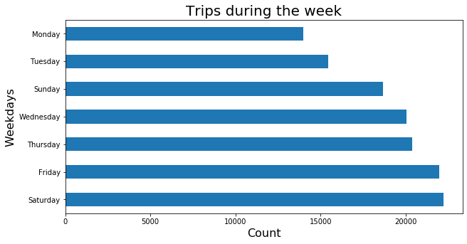

```python
# weekdays plot
plt.figure(figsize=(10, 5))
baywheelstrip_clean['weekday'].value_counts().plot(kind = 'barh');
plt.title("Trips during the week", fontsize = 20)
plt.ylabel("Weekdays", fontsize = 16);
plt.xlabel("Count", fontsize = 16);
```

**Bivariate Exploration**

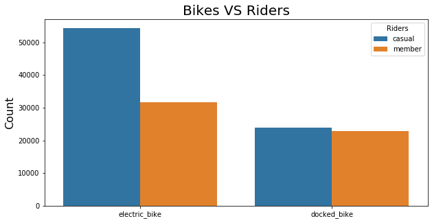

```python
# Relationship between bikes and riders
plt.figure(figsize=(10, 5))
ax = sns.countplot(data = baywheelstrip_clean,
              x = 'rideable_type', hue = 'member_casual');

plt.title("Bikes VS Riders", fontsize = 20)
plt.xlabel("");
plt.ylabel("Count", fontsize = 16);
ax.legend(loc = 0, title = 'Riders');
```

**comment:**

- Casual riders favourite electric bikes twice docked bikes

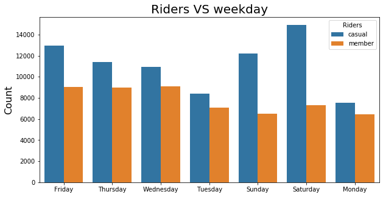

```python
# Relationship between riders and weekdays
plt.figure(figsize=(10, 5))
ax = sns.countplot(data = baywheelstrip_clean,
              x = 'weekday', hue = 'member_casual');

plt.title("Riders VS weekday", fontsize = 20)
plt.xlabel("");
plt.ylabel("Count", fontsize = 16);
ax.legend(loc = 0, title = 'Riders');
```

**comment:**

- Casual riders are twice members riders in weekends

**Multivariate Exploration**

```python
# Create new column for time users trip
baywheelstrip_clean['time_hour'] = baywheelstrip_clean['started_at'].dt.hour
```

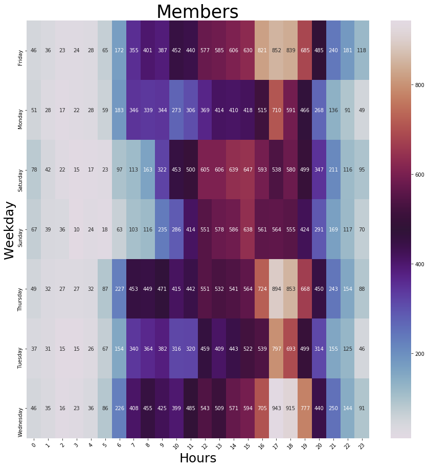

```python
# Plot heatmap for members
plt.figure(figsize=(15, 15))

member_bikes = baywheelstrip_clean.query('member_casual == "member"').groupby(['time_hour', 'weekday'])['ride_id'].size().reset_index();
# member_bikes = member_bikes.pivot('time_hour', 'weekday', 'ride_id')
member_bikes = member_bikes.pivot('weekday', 'time_hour', 'ride_id')

hot_map = sns.heatmap(member_bikes, cmap = 'twilight', annot=True, fmt="d")

plt.title("Members", fontsize = 35)
plt.ylabel('Weekday', fontsize = 25)
plt.xlabel('Hours', fontsize = 25);
plt.xticks(rotation = 45)
plt.show()
```

**comment:**

- Members ride in main hours(11 ~ 19). They also ride more on workdays

# Conclusion

- Highest 3 trip days were on Saturday. While, least 4 trip days were on Monday.
- Riders used Electric bikes twice docked bikes. espashily casual riders
- Casual riders are twice members riders in weekends
- Members ride main hours(11 ~ 19). They also ride more on workdays

Innovate services like public bicycle sharing system is [less pollution in the air and less traffic, allows more parking spots, and is less noisy through neighborhoods.](https://www.bikeradar.com/features/9-reasons-why-bike-commuting-is-better-than-driving/#:~:text=Bike%20commuting%20helps%20society%20in,is%20less%20noisy%20through%20neighborhoods)

# Sources

- [IPython tutorial](https://stackoverflow.com/questions/11854847/how-can-i-display-an-image-from-a-file-in-jupyter-notebook)
- [Seaborn heatmap documentation](https://seaborn.pydata.org/generated/seaborn.heatmap.html)